# Unsupervised Learning - An Example of Movie Reviews

## Dataset

Let us import a dataset of movie reviews by different users.

```python
import pandas as pd
ratings = pd.read_csv("user_movie1000_ratings.csv")
ratings.head()
```

|  | user_ID | Forrest Gump (1994) | Pulp Fiction (1994) | Shawshank Redemption, The (1994) | Silence of the Lambs, The (1991) | Star Wars: Episode IV - A New Hope (1977) | Jurassic Park (1993) | Matrix, The (1999) | Toy Story (1995) | Schindler's List (1993) | ... | Insomnia (2002) | What Lies Beneath (2000) | Roman Holiday (1953) | Motorcycle Diaries, The (Diarios de motocicleta) (2004) | Sophie's Choice (1982) | Dawn of the Dead (2004) | Ocean's Thirteen (2007) | Seabiscuit (2003) | Easy Rider (1969) | Lucky Number Slevin (2006) |
| --- | --- | --- | --- | --- | --- | --- | --- | --- | --- | --- | --- | --- | --- | --- | --- | --- | --- | --- | --- | --- | --- |
| 0 | 547 | 2.0 | 5.0 | 5.0 | 5.0 | NaN | 3.0 | 3.5 | 3.5 | 5.0 | ... | 2.5 | 2.0 | NaN | NaN | 4.0 | 4.5 | 3.0 | NaN | 5.0 | 3.0 |
| 1 | 564 | 3.0 | 5.0 | NaN | 5.0 | 2.0 | 5.0 | 3.0 | 4.0 | 4.0 | ... | NaN | 4.0 | NaN | NaN | 5.0 | NaN | NaN | NaN | NaN | NaN |
| 2 | 624 | 3.0 | 5.0 | NaN | 5.0 | 5.0 | 3.0 | 2.0 | 5.0 | NaN | ... | 3.5 | NaN | NaN | NaN | NaN | NaN | 3.0 | NaN | 4.0 | 3.5 |
| 3 | 15 | 1.0 | 5.0 | 2.0 | 5.0 | 5.0 | 3.0 | 5.0 | 2.0 | 4.0 | ... | 2.0 | 2.0 | 1.0 | NaN | NaN | NaN | 3.5 | NaN | 2.5 | 1.0 |
| 4 | 73 | 5.0 | 5.0 | 5.0 | 4.5 | 4.5 | 4.0 | 4.5 | 5.0 | 5.0 | ... | 3.0 | NaN | NaN | NaN | NaN | 3.0 | 2.0 | 2.5 | NaN | 4.0 |

5 rows × 1001 columns

Let's check the shape of the DataFrame.

```python
ratings.shape
```

```
(671, 1001)
```

As we can see, there are

- 671 users (each row represents reviews submitted by a user)
- 1000 movies reviewed by the users
- not every user reviews every movie -- each NA value indicates that a user did not review the corresponding movie

Let's drop the `user_ID` column as it does not provide useful information.

```python
ratings = ratings.drop('user_ID',axis=1)
ratings.head()
```

|  | Forrest Gump (1994) | Pulp Fiction (1994) | Shawshank Redemption, The (1994) | Silence of the Lambs, The (1991) | Star Wars: Episode IV - A New Hope (1977) | Jurassic Park (1993) | Matrix, The (1999) | Toy Story (1995) | Schindler's List (1993) | Terminator 2: Judgment Day (1991) | ... | Insomnia (2002) | What Lies Beneath (2000) | Roman Holiday (1953) | Motorcycle Diaries, The (Diarios de motocicleta) (2004) | Sophie's Choice (1982) | Dawn of the Dead (2004) | Ocean's Thirteen (2007) | Seabiscuit (2003) | Easy Rider (1969) | Lucky Number Slevin (2006) |
| --- | --- | --- | --- | --- | --- | --- | --- | --- | --- | --- | --- | --- | --- | --- | --- | --- | --- | --- | --- | --- | --- |
| 0 | 2.0 | 5.0 | 5.0 | 5.0 | NaN | 3.0 | 3.5 | 3.5 | 5.0 | NaN | ... | 2.5 | 2.0 | NaN | NaN | 4.0 | 4.5 | 3.0 | NaN | 5.0 | 3.0 |
| 1 | 3.0 | 5.0 | NaN | 5.0 | 2.0 | 5.0 | 3.0 | 4.0 | 4.0 | 5.0 | ... | NaN | 4.0 | NaN | NaN | 5.0 | NaN | NaN | NaN | NaN | NaN |
| 2 | 3.0 | 5.0 | NaN | 5.0 | 5.0 | 3.0 | 2.0 | 5.0 | NaN | 3.0 | ... | 3.5 | NaN | NaN | NaN | NaN | NaN | 3.0 | NaN | 4.0 | 3.5 |
| 3 | 1.0 | 5.0 | 2.0 | 5.0 | 5.0 | 3.0 | 5.0 | 2.0 | 4.0 | 4.0 | ... | 2.0 | 2.0 | 1.0 | NaN | NaN | NaN | 3.5 | NaN | 2.5 | 1.0 |
| 4 | 5.0 | 5.0 | 5.0 | 4.5 | 4.5 | 4.0 | 4.5 | 5.0 | 5.0 | 3.0 | ... | 3.0 | NaN | NaN | NaN | NaN | 3.0 | 2.0 | 2.5 | NaN | 4.0 |

5 rows × 1000 columns

Let's visualize the reviews by a heatmap.

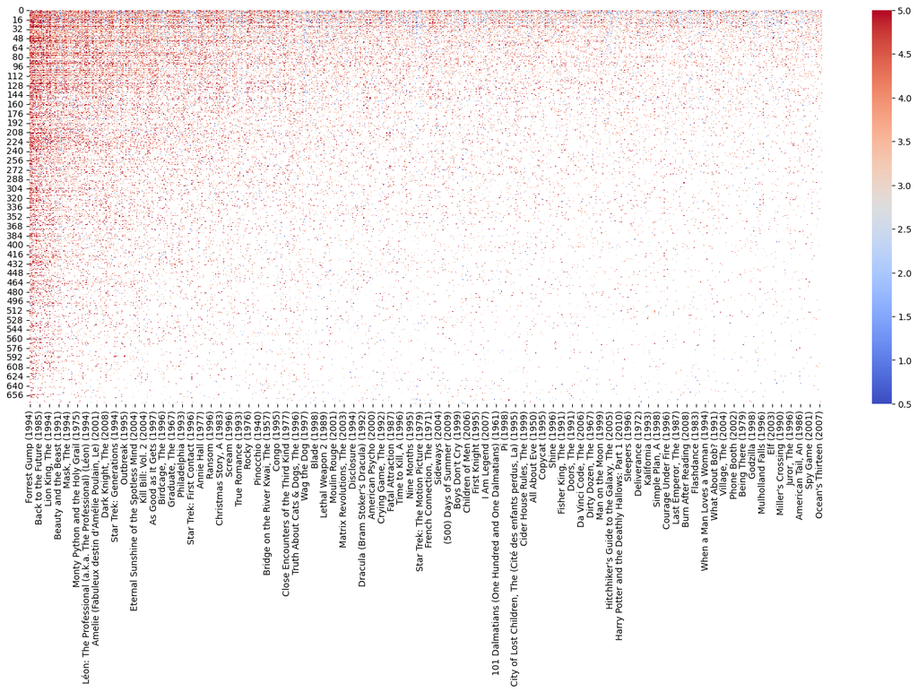

```python
import matplotlib.pyplot as plt
import seaborn as sns

plt.figure(figsize=(20,8))
sns.heatmap(ratings,cmap='coolwarm')
plt.show()
```

Given the large number of movies and users, let's focus on the first 20 users and first 30 movies.

We can use the argument `annot=True` to show the rating in each cell.

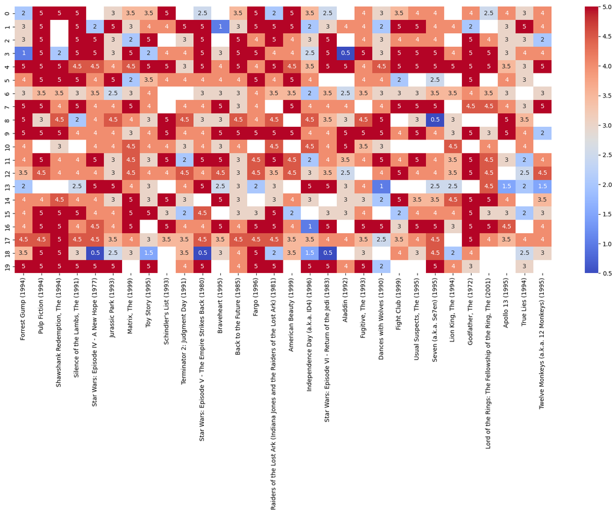

```python
plt.figure(figsize=(20,8))
sns.heatmap(ratings_no_uid.iloc[0:20,0:30],cmap='coolwarm',annot=True)
plt.show()
```

## Question

If a user didn't rate a movie, how can we predict their rating of the movie?

- For example, the **second user** did not rate the movie **Shawshank Redemption (1994)**. What would be their rating if they decide to watch and rate that movie?

**The Supervised Learning Approach**

- Consider users' ratings of other movie as "features", and the rating of the "focal movie" (e.g., Shawshank Redemption (1994)). Then we can build a regression/classification model.
- Challenges?

**The Unsupervised Learning Approach**

## Clustering

Clustering is the process of **dividing a dataset into groups** where points in the same group (or cluster) are more similar to each other than to those in other clusters.

### $k$-Means Clustering

In $k$-means clustering,

- there are $k$ clusters in total, each of which is represented by centeroid
- the clusters are created so as to minimize the intra-cluster distance, which is the squared distance between the data points and the centroid of the cluster they belongs to.

To use $k$-means clustering, we will first need to impute the missing values, and then scale the data.

Let's first replace the `NA` values by 0.

```python
ratings_imputed = ratings.fillna(0)
```

Next, we may need to scale the data. Note that since $k$-means clustering is a distance-based method, in general we need to perform scaling. However, currently all columns are on the same scale of 0 to 5 (since all columns are ratings of 0 to 5).

To perform $k$-means clustering, we need to import the `KMeans` function from `sklearn`.

Suppose that we would like to divie the dataset into 10 clusters.

```python
from sklearn.cluster import KMeans

k = 10

#build the k-means model
kmeans_model = KMeans(n_clusters=k,random_state=18)

#perform the clustering by fitting the model to the data

kmeans_model.fit(ratings_imputed)
```

```
KMeans(n_clusters=10, random_state=18)
```

The fitted model has a few useful attributes.

The `.cluster_centers_` attribute gives the coordinates of the centroids. We may think of a centroid as the ratings of a representative user in a cluster.

```python
pd.DataFrame(kmeans_model.cluster_centers_,columns=ratings.columns)
```

|  | Forrest Gump (1994) | Pulp Fiction (1994) | Shawshank Redemption, The (1994) | Silence of the Lambs, The (1991) | Star Wars: Episode IV - A New Hope (1977) | Jurassic Park (1993) | Matrix, The (1999) | Toy Story (1995) | Schindler's List (1993) | Terminator 2: Judgment Day (1991) | ... | Insomnia (2002) | What Lies Beneath (2000) | Roman Holiday (1953) | Motorcycle Diaries, The (Diarios de motocicleta) (2004) | Sophie's Choice (1982) | Dawn of the Dead (2004) | Ocean's Thirteen (2007) | Seabiscuit (2003) | Easy Rider (1969) | Lucky Number Slevin (2006) |
| --- | --- | --- | --- | --- | --- | --- | --- | --- | --- | --- | --- | --- | --- | --- | --- | --- | --- | --- | --- | --- | --- |
| 0 | 3.329412 | 3.388235 | 3.035294 | 3.258824 | 0.764706 | 3.164706 | 0.047059 | 1.094118 | 2.035294 | 2.729412 | ... | 5.551115e-17 | -2.775558e-17 | 5.551115e-17 | 1.110223e-16 | 0.000000 | -1.110223e-16 | 8.326673e-17 | 1.110223e-16 | 8.326673e-17 | 8.326673e-17 |
| 1 | 2.677852 | 1.989933 | 2.221477 | 1.909396 | 3.107383 | 1.879195 | 3.104027 | 2.013423 | 1.825503 | 2.090604 | ... | 4.362416e-02 | 1.040268e-01 | 8.389262e-02 | 4.697987e-02 | 0.093960 | 7.718121e-02 | 1.208054e-01 | 1.711409e-01 | 7.718121e-02 | 5.704698e-02 |
| 2 | 0.846032 | 0.979365 | 1.142857 | 0.866667 | 0.930159 | 0.441270 | 0.584127 | 0.715873 | 0.761905 | 0.323810 | ... | 2.539683e-02 | 6.666667e-02 | 7.301587e-02 | 8.412698e-02 | 0.077778 | 2.063492e-02 | 4.603175e-02 | 2.698413e-02 | 9.523810e-03 | -4.163336e-16 |
| 3 | 3.583333 | 4.708333 | 3.916667 | 4.416667 | 4.000000 | 3.416667 | 4.000000 | 3.333333 | 3.375000 | 2.916667 | ... | 2.750000e+00 | 9.583333e-01 | 3.750000e-01 | 1.333333e+00 | 1.208333 | 6.250000e-01 | 1.375000e+00 | 2.250000e+00 | 2.416667e+00 | 1.291667e+00 |
| 4 | 3.000000 | 3.704545 | 4.045455 | 3.772727 | 4.045455 | 2.704545 | 1.795455 | 2.590909 | 4.090909 | 2.204545 | ... | 1.818182e-01 | 1.818182e-01 | 2.022727e+00 | 2.045455e-01 | 2.227273 | -8.326673e-17 | 4.163336e-17 | 5.227273e-01 | 1.090909e+00 | 2.775558e-17 |
| 5 | 4.500000 | 5.000000 | 5.000000 | 4.250000 | 4.750000 | 3.750000 | 4.750000 | 4.750000 | 2.500000 | 4.250000 | ... | 3.750000e+00 | 0.000000e+00 | 0.000000e+00 | 0.000000e+00 | 0.000000 | 0.000000e+00 | 0.000000e+00 | 2.250000e+00 | 0.000000e+00 | 0.000000e+00 |
| 6 | 3.470588 | 3.950980 | 3.333333 | 3.000000 | 2.460784 | 1.764706 | 3.656863 | 2.656863 | 2.813725 | 1.441176 | ... | 1.666667e-01 | 1.764706e-01 | 1.568627e-01 | 6.568627e-01 | 0.000000 | 4.705882e-01 | 4.019608e-01 | 1.764706e-01 | 1.862745e-01 | 9.215686e-01 |
| 7 | 3.825000 | 4.000000 | 3.925000 | 3.200000 | 3.350000 | 3.725000 | 4.325000 | 2.300000 | 1.900000 | 4.275000 | ... | 4.750000e-01 | 4.750000e-01 | 2.775558e-17 | 4.000000e-01 | 0.000000 | 1.400000e+00 | 5.750000e-01 | 4.750000e-01 | 5.250000e-01 | 1.025000e+00 |
| 8 | 4.125000 | 3.958333 | 3.250000 | 4.416667 | 4.625000 | 3.833333 | 4.458333 | 3.416667 | 3.250000 | 3.833333 | ... | 7.916667e-01 | 4.583333e-01 | 6.666667e-01 | 0.000000e+00 | 0.000000 | 6.250000e-01 | 1.387779e-17 | 0.000000e+00 | 3.333333e-01 | 3.750000e-01 |
| 9 | 4.333333 | 3.000000 | 4.333333 | 3.000000 | 4.333333 | 3.000000 | 3.166667 | 3.000000 | 3.000000 | 2.333333 | ... | 2.775558e-17 | 1.333333e+00 | 1.333333e+00 | 0.000000e+00 | 1.000000 | 0.000000e+00 | 1.387779e-17 | 0.000000e+00 | 5.000000e-01 | 2.775558e-17 |

10 rows × 1000 columns

The `.labels_` attribute is the cluster labels for each data point in the dataset.

Each label is a number between 0 and $k-1$, indicating one of the $k$ clusters.

```python
kmeans_model.labels_
```

```
array([3, 4, 3, 3, 3, 3, 3, 3, 4, 4, 9, 3, 3, 7, 3, 4, 3, 3, 7, 9, 8, 4,
       4, 6, 6, 4, 4, 5, 4, 4, 4, 7, 6, 7, 7, 6, 4, 7, 7, 4, 7, 8, 1, 6,
       9, 5, 4, 8, 6, 7, 1, 8, 4, 4, 6, 7, 4, 8, 2, 6, 6, 7, 7, 1, 6, 6,
       6, 1, 1, 8, 1, 6, 8, 8, 4, 8, 7, 0, 7, 4, 1, 6, 8, 2, 1, 6, 1, 1,
       6, 8, 4, 7, 6, 6, 2, 7, 1, 1, 6, 6, 6, 1, 6, 7, 6, 1, 7, 6, 6, 6,
       8, 1, 1, 6, 1, 7, 1, 1, 6, 1, 1, 1, 2, 6, 4, 6, 1, 1, 1, 6, 1, 1,
       6, 1, 6, 1, 6, 1, 6, 6, 7, 6, 1, 1, 6, 0, 6, 1, 1, 1, 4, 2, 2, 0,
       2, 2, 6, 1, 1, 1, 1, 6, 1, 1, 1, 1, 2, 1, 1, 6, 2, 1, 6, 1, 6, 6,
       1, 0, 1, 1, 2, 1, 0, 1, 2, 2, 1, 0, 0, 0, 1, 2, 0, 1, 1, 1, 2, 1,
       0, 2, 1, 1, 1, 1, 1, 1, 1, 0, 1, 1, 0, 2, 1, 1, 6, 1, 1, 1, 0, 1,
       1, 0, 1, 1, 2, 0, 6, 1, 1, 6, 1, 0, 6, 1, 1, 1, 2, 1, 1, 1, 2, 1,
       1, 2, 2, 2, 0, 0, 0, 2, 2, 1, 1, 1, 0, 6, 2, 0, 1, 1, 0, 1, 2, 0,
       2, 2, 1, 1, 2, 1, 1, 1, 1, 2, 2, 1, 6, 1, 1, 2, 2, 0, 0, 0, 1, 0,
       2, 2, 1, 0, 2, 1, 0, 2, 2, 1, 2, 1, 1, 2, 1, 2, 1, 1, 1, 1, 0, 1,
       1, 1, 2, 1, 2, 2, 1, 1, 0, 1, 2, 2, 0, 0, 2, 2, 1, 2, 1, 2, 1, 1,
```

[output cut: 16 more lines]

Let's append the labels to the original dataset as a column.

```python
ratings['cluster_label'] = kmeans_model.labels_
ratings.head()
```

|  | Forrest Gump (1994) | Pulp Fiction (1994) | Shawshank Redemption, The (1994) | Silence of the Lambs, The (1991) | Star Wars: Episode IV - A New Hope (1977) | Jurassic Park (1993) | Matrix, The (1999) | Toy Story (1995) | Schindler's List (1993) | Terminator 2: Judgment Day (1991) | ... | What Lies Beneath (2000) | Roman Holiday (1953) | Motorcycle Diaries, The (Diarios de motocicleta) (2004) | Sophie's Choice (1982) | Dawn of the Dead (2004) | Ocean's Thirteen (2007) | Seabiscuit (2003) | Easy Rider (1969) | Lucky Number Slevin (2006) | cluster_label |
| --- | --- | --- | --- | --- | --- | --- | --- | --- | --- | --- | --- | --- | --- | --- | --- | --- | --- | --- | --- | --- | --- |
| 0 | 2.0 | 5.0 | 5.0 | 5.0 | NaN | 3.0 | 3.5 | 3.5 | 5.0 | NaN | ... | 2.0 | NaN | NaN | 4.0 | 4.5 | 3.0 | NaN | 5.0 | 3.0 | 3 |
| 1 | 3.0 | 5.0 | NaN | 5.0 | 2.0 | 5.0 | 3.0 | 4.0 | 4.0 | 5.0 | ... | 4.0 | NaN | NaN | 5.0 | NaN | NaN | NaN | NaN | NaN | 4 |
| 2 | 3.0 | 5.0 | NaN | 5.0 | 5.0 | 3.0 | 2.0 | 5.0 | NaN | 3.0 | ... | NaN | NaN | NaN | NaN | NaN | 3.0 | NaN | 4.0 | 3.5 | 3 |
| 3 | 1.0 | 5.0 | 2.0 | 5.0 | 5.0 | 3.0 | 5.0 | 2.0 | 4.0 | 4.0 | ... | 2.0 | 1.0 | NaN | NaN | NaN | 3.5 | NaN | 2.5 | 1.0 | 3 |
| 4 | 5.0 | 5.0 | 5.0 | 4.5 | 4.5 | 4.0 | 4.5 | 5.0 | 5.0 | 3.0 | ... | NaN | NaN | NaN | NaN | 3.0 | 2.0 | 2.5 | NaN | 4.0 | 3 |

5 rows × 1001 columns

The `.inertia` attribute returns the the sum of squared distances of data points to their nearest cluster centroid.

- It measures how compact the clusters are, with lower values indicating points in the same cluster closer each other.
- It does not measure clustering quality in an absolute sense but can be used to compare different values of $k$.

```python
kmeans_model.inertia_
```

```
595829.2661796947
```

But how do we find the appropriate number of clusters?

### The Elbow Method

The elbow method is a heuristic to determine the value of $k$.

- The method evaluates the inertia for $k=1,2,3,...$.
- As $k$ increases, inertia tend to decrease (why?)
- The methods identifies the **elbow point**, at which inertia stops decreasing rapidly.

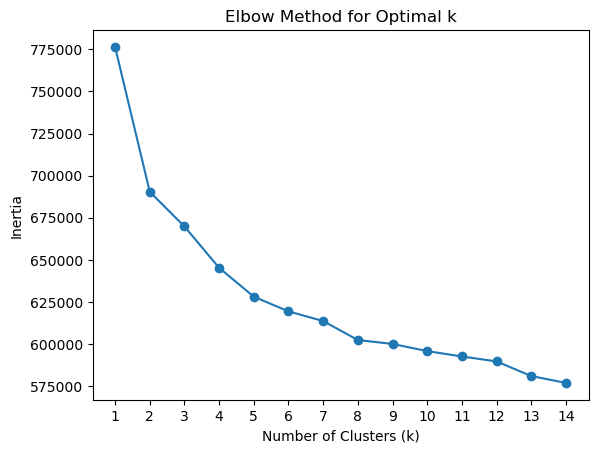

```python
inertia = []
k_range = range(1,15)

for k in k_range:
    kmeans = KMeans(n_clusters=k,random_state=18)
    kmeans.fit(ratings_imputed)
    inertia.append(kmeans.inertia_)

plt.plot(k_range, inertia, marker='o')
plt.title('Elbow Method for Optimal k')
plt.xticks(k_range)
plt.xlabel('Number of Clusters (k)')
plt.ylabel('Inertia')
plt.show()
```

From the chart:

- The curve shows a noticeable drop in inertia from $k=1$ to $k=5$.
- After $k=5$, the rate of decrease becomes less pronounced and more gradual.

Let's set `n_clusters` to 5 and redo the clustering.

```python
kmeans = KMeans(n_clusters=5,random_state=18)
kmeans.fit(ratings_imputed)
```

```
KMeans(n_clusters=5, random_state=18)
```

Let's assign the labels to the last column of the `ratings` DataFrame (the dataset after droping the `user_ID` column).

```python
ratings['cluster_label']=kmeans.labels_
ratings.head()
```

|  | Forrest Gump (1994) | Pulp Fiction (1994) | Shawshank Redemption, The (1994) | Silence of the Lambs, The (1991) | Star Wars: Episode IV - A New Hope (1977) | Jurassic Park (1993) | Matrix, The (1999) | Toy Story (1995) | Schindler's List (1993) | Terminator 2: Judgment Day (1991) | ... | What Lies Beneath (2000) | Roman Holiday (1953) | Motorcycle Diaries, The (Diarios de motocicleta) (2004) | Sophie's Choice (1982) | Dawn of the Dead (2004) | Ocean's Thirteen (2007) | Seabiscuit (2003) | Easy Rider (1969) | Lucky Number Slevin (2006) | cluster_label |
| --- | --- | --- | --- | --- | --- | --- | --- | --- | --- | --- | --- | --- | --- | --- | --- | --- | --- | --- | --- | --- | --- |
| 0 | 2.0 | 5.0 | 5.0 | 5.0 | NaN | 3.0 | 3.5 | 3.5 | 5.0 | NaN | ... | 2.0 | NaN | NaN | 4.0 | 4.5 | 3.0 | NaN | 5.0 | 3.0 | 3 |
| 1 | 3.0 | 5.0 | NaN | 5.0 | 2.0 | 5.0 | 3.0 | 4.0 | 4.0 | 5.0 | ... | 4.0 | NaN | NaN | 5.0 | NaN | NaN | NaN | NaN | NaN | 3 |
| 2 | 3.0 | 5.0 | NaN | 5.0 | 5.0 | 3.0 | 2.0 | 5.0 | NaN | 3.0 | ... | NaN | NaN | NaN | NaN | NaN | 3.0 | NaN | 4.0 | 3.5 | 3 |
| 3 | 1.0 | 5.0 | 2.0 | 5.0 | 5.0 | 3.0 | 5.0 | 2.0 | 4.0 | 4.0 | ... | 2.0 | 1.0 | NaN | NaN | NaN | 3.5 | NaN | 2.5 | 1.0 | 3 |
| 4 | 5.0 | 5.0 | 5.0 | 4.5 | 4.5 | 4.0 | 4.5 | 5.0 | 5.0 | 3.0 | ... | NaN | NaN | NaN | NaN | 3.0 | 2.0 | 2.5 | NaN | 4.0 | 3 |

5 rows × 1001 columns

As we can see, the second user has the cluster label 3.

We can visualize the clusters using the heatmap.

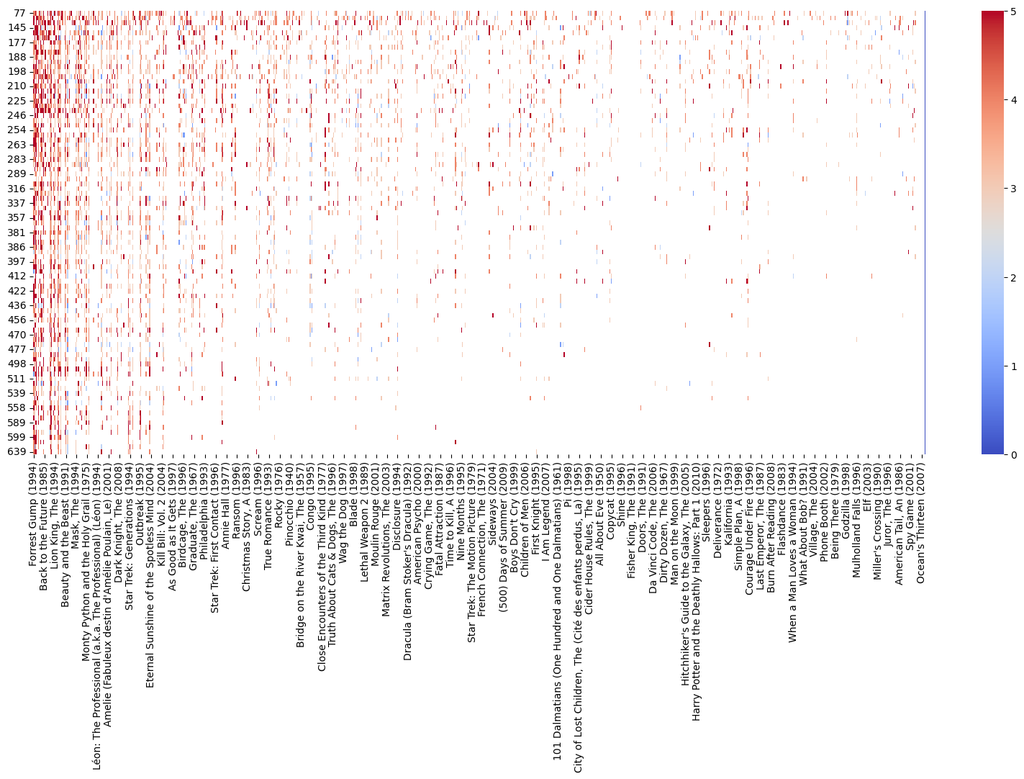

```python
c = 0

ratings_c = ratings[ratings_no_uid['cluster_label']==c]

plt.figure(figsize=(20,8))
sns.heatmap(ratings_c,cmap='coolwarm')
plt.show()
```

We will sort the rows according to their cluster labels, so that in the DataFrame the rows of the same cluster are grouped together.

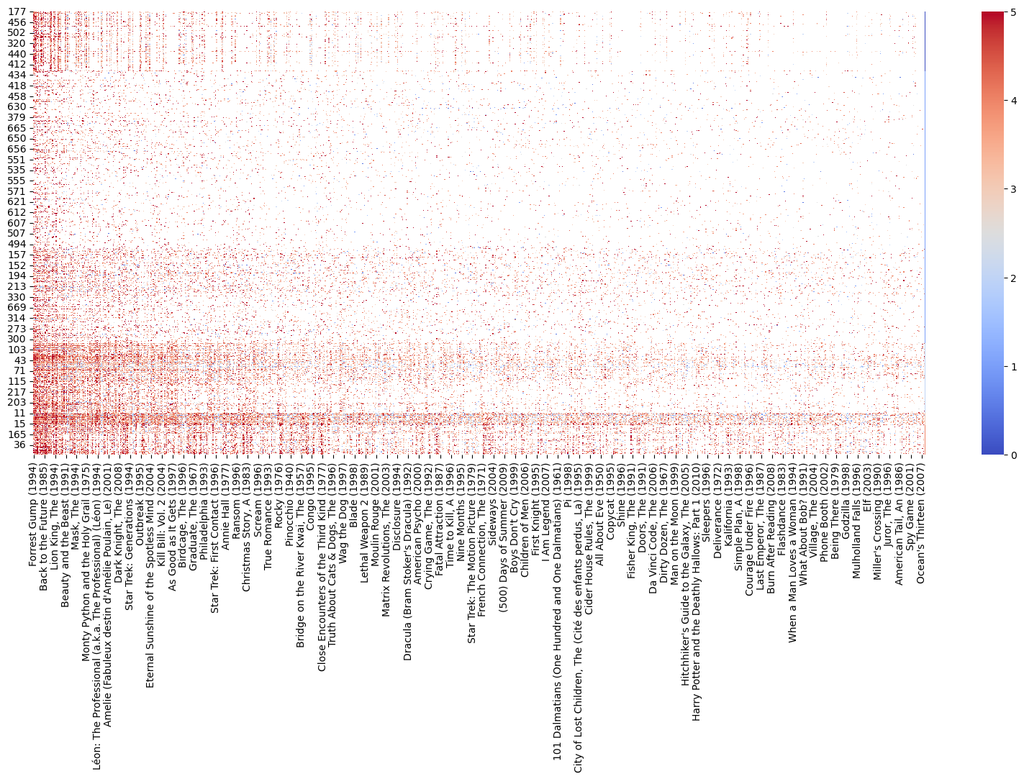

```python
ratings_sorted = ratings.sort_values(by='cluster_label')

plt.figure(figsize=(20,8))
sns.heatmap(ratings_sorted,cmap='coolwarm')
plt.show()
```

Next, let's group the `ratings` DataFrame and calculate the average ratings of the movies of each group.

```python
grouped = ratings_no_uid.groupby(ratings_no_uid['cluster_label'])
ratings_by_cluster = grouped.mean()
ratings_by_cluster
```

| cluster_label | Forrest Gump (1994) | Pulp Fiction (1994) | Shawshank Redemption, The (1994) | Silence of the Lambs, The (1991) | Star Wars: Episode IV - A New Hope (1977) | Jurassic Park (1993) | Matrix, The (1999) | Toy Story (1995) | Schindler's List (1993) | Terminator 2: Judgment Day (1991) | ... | Insomnia (2002) | What Lies Beneath (2000) | Roman Holiday (1953) | Motorcycle Diaries, The (Diarios de motocicleta) (2004) | Sophie's Choice (1982) | Dawn of the Dead (2004) | Ocean's Thirteen (2007) | Seabiscuit (2003) | Easy Rider (1969) | Lucky Number Slevin (2006) |
| --- | --- | --- | --- | --- | --- | --- | --- | --- | --- | --- | --- | --- | --- | --- | --- | --- | --- | --- | --- | --- | --- |
| 0 | 4.109589 | 4.026316 | 4.696429 | 4.409091 | 4.722222 | 3.946667 | 4.333333 | 4.035714 | 4.476190 | 4.047619 | ... | NaN | NaN | NaN | NaN | NaN | NaN | NaN | NaN | NaN | NaN |
| 1 | 4.116935 | 4.247826 | 4.428030 | 3.982301 | 4.147059 | 3.670588 | 4.126016 | 3.816832 | 4.223404 | 3.862319 | ... | 3.833333 | 3.150000 | 3.833333 | 3.750000 | 4.083333 | 3.666667 | 3.666667 | 4.125 | 3.500000 | 4.333333 |
| 2 | 4.119565 | 4.365854 | 4.473684 | 4.060811 | 4.131250 | 3.500000 | 4.277174 | 3.876712 | 4.110169 | 4.169492 | ... | 3.285714 | 3.357143 | 4.000000 | 3.461538 | NaN | 3.325000 | 3.269231 | 3.875 | 4.125000 | 3.970588 |
| 3 | 3.666667 | 4.722222 | 4.375000 | 4.472222 | 4.147059 | 3.694444 | 3.972222 | 3.843750 | 4.392857 | 3.718750 | ... | 3.266667 | 2.571429 | 2.833333 | 4.000000 | 4.083333 | 3.750000 | 2.750000 | 3.600 | 3.611111 | 3.100000 |
| 4 | 3.735294 | 4.287879 | 4.451613 | 4.121212 | 4.462500 | 3.685185 | 4.260870 | 3.913793 | 4.600000 | 4.083333 | ... | 3.000000 | 3.500000 | 4.333333 | 4.500000 | 4.000000 | NaN | NaN | 4.000 | 3.722222 | NaN |

5 rows × 1000 columns

The result DataFrame shows the average ratings of the movies of each cluster.